# Multiple Testing: Introduction

## Readings

- Curran-Everett D (2000) Multiple comparisons: philosophies and illustrations. *Am J Physiol Regul Integr Comp Physiol* 279:R1-8.

## Resources

- http://www.nicebread.de/whats-the-probability-that-a-significant-p-value-indicates-a-true-effect/
- Bretz F, Hothorn T, Westfall P (2010) *Multiple Comparisons Using R*. Boca Raton, FL: Taylor & Francis.
- Curran-Everett D, Benos DJ (2007) Guidelines for reporting statistics in journals published by the American Physiological Society: the sequel. *Adv Physiol Educ* 31:295-298.
- Hothorn T, Bretz F, Westfall P (2008) Simultaneous inference in general parametric models. *Biom J* 50:346–363.
- Ioannidis JPA (2005) Why most published research findings are false. *PLoS Med* 2:e124.
- Storey JD, Tibshirani R (2003) Statistical significance for genomewide studies. *Proc Natl Acad Sci USA* 100:9440–9445.

## Significance Testing Mistakes

Mistake #1: Concluding there IS an effect when there IS NOT actually an effect.

```r
set.seed(10)
nn <- 10
group1.mean <- 6
group2.mean <- 6
yy <- c(rnorm(nn, group1.mean, 1),rnorm(nn, group2.mean, 1))
gg <- c(rep('a',nn), rep('b',nn))
summary(lm(yy ~ gg))$coefficients
```

```
##              Estimate Std. Error   t value                Pr(>|t|)
## (Intercept) 5.5093432  0.2167578 25.417051 0.000000000000001483964
## ggb         0.8602484  0.3065418  2.806301 0.011677945900063151086
```

This is a Type I error = A false positive = A false discovery

## Significance Testing Mistakes

Mistake #2: Concluding there IS NOT an effect when there IS actually an effect.

```r
set.seed(93)
nn <- 10
group1.mean <- 5
group2.mean <- 6
yy <- c(rnorm(nn, group1.mean, 1), rnorm(nn, group2.mean, 1))
gg <- c(rep('a', nn), rep('b', nn))
summary(lm(yy ~ gg))$coefficients
```

```
##              Estimate Std. Error   t value             Pr(>|t|)
## (Intercept) 5.5837026  0.3359147 16.622383 0.000000000002284901
## ggb         0.6398448  0.4750551  1.346885 0.194731320450884815
```

This is a Type II error = False Negative

## Types of errors and statistical power

|  | Reject H<sub>0</sub> | Fail to reject H<sub>0</sub> |
| --- | --- | --- |
| H<sub>0</sub> is true | Type I error | *Correct* |
| H<sub>0</sub> is false | *Correct* | Type II error |

Type I error occurs when:

- *P* is small by *random chance*, given that \(\alpha\) is chosen ahead of the test

Type II error probability depends on:

- The value of \(\alpha\)
- How “wrong” H<sub>0</sub> is

## Problems of Multiplicity

If you set a Type I error rate (\(\alpha\)) of 0.05 for any one test and then perform more than one such test on related data:

- The overall Type I error rate for all your tests together (familywise) is greater than 0.05
- You will be more likely than 5% to erroneously reject a *true* null hypothesis.
- You will claim a significant effect when one does not exist.

## Problems of Multiplicity

```r
set.seed(3210)
nn <- 10
group1.mean <- 6
group2.mean <- 6
niter <- 1000
ps<-data.frame('p1' = numeric(length = niter),
               'p2' = numeric(length = niter))

for(ii in 1:niter) {
  yy1 <- c(rnorm(nn, group1.mean, 1),rnorm(nn, group2.mean, 1))
  yy2 <- c(rnorm(nn, group1.mean, 1),rnorm(nn, group2.mean, 1))
  gg <- c(rep('a',nn), rep('b',nn))
  ps[ii,1] <- summary(lm(yy1 ~ gg))$coefficients[2,4]
  ps[ii,2] <- summary(lm(yy2 ~ gg))$coefficients[2,4]
}
```

## Problems of Multiplicity

What is the probability of a false positive for yy1?

```r
cbind(ps[c(8, 12), ], c("FP", "x"))
```

```
##            p1        p2 c("FP", "x")
## 8  0.03907693 0.7073702           FP
## 12 0.07440324 0.0249441            x
```

```r
mean(ps[, 'p1'] < 0.05)
```

```
## [1] 0.044
```

## Problems of Multiplicity

What is the probability of a false positive for yy2?

```r
cbind(ps[c(8, 12),], c("x", "FP"))
```

```
##            p1        p2 c("x", "FP")
## 8  0.03907693 0.7073702            x
## 12 0.07440324 0.0249441           FP
```

```r
mean(ps[, 'p2'] < 0.05)
```

```
## [1] 0.053
```

## Problems of Multiplicity

What is the probability of a false positive for yy1 or yy2?

```r
cbind(ps[c(8, 12, 13), ], c("FP", "FP", "x"))
```

```
##            p1        p2 c("FP", "FP", "x")
## 8  0.03907693 0.7073702                 FP
## 12 0.07440324 0.0249441                 FP
## 13 0.11460592 0.2811390                  x
```

```r
length(which(ps[, 'p1'] < 0.05 | ps[, 'p2'] < 0.05)) / niter
```

```
## [1] 0.095
```

The overall error rate = the family-wise error rate (FWER).

## Week 7: Post hoc tests for ANOVA

Significant ANOVA (*P* = 0.004) only says that at least one mean is different.

Many options are available for post hoc (unplanned) comparisons:

- Scheffé test
- Duncan’s multiple range test
- Fisher’s least significant difference test
- Newman-Keuls test
- Tukey-Kramer test (Tukey’s Honestly Significant Difference)

We’ll use the Tukey-Kramer test (only one you need to know right now)

## Tukey-Kramer test

- Assumes that we have already performed an ANOVA and rejected the null hypothesis
  - If the overall ANOVA is not significant, then a post hoc test makes no sense.
- The familywise error rate (FWER) with a Tukey-Kramer test is no larger than \(\alpha\).
  - FWER is the overall probability of a Type I error
- Tukey-Kramer test makes all the same assumptions as ANOVA.
  - Defaults to all pairwise combinations of levels

## Tukey-Kramer test: `multcomp` library

- Alternative but less general: `TukeyHSD()` in R
  - Only takes an object from `aov()`

```r
tukey <- glht(fm_lm, linfct = mcp(Treatment = "Tukey"))
summary(tukey)
```

```
##
##   Simultaneous Tests for General Linear Hypotheses
##
## Multiple Comparisons of Means: Tukey Contrasts
##
##
## Fit: lm(formula = Shift ~ Treatment, data = JL)
##
## Linear Hypotheses:
##                     Estimate Std. Error t value Pr(>|t|)
## eyes - control == 0 -1.24268    0.36433  -3.411  0.00802 **
## knee - control == 0 -0.02696    0.36433  -0.074  0.99698
## knee - eyes == 0     1.21571    0.37628   3.231  0.01175 *
## ---
## Signif. codes:  0 '***' 0.001 '**' 0.01 '*' 0.05 '.' 0.1 ' ' 1
## (Adjusted p values reported -- single-step method)
```

## Selective Set of Comparisons

```r
post_hoc <- glht(fm_lm,
                 mcp(Treatment = c("eyes - control = 0",
                                   "knee - control = 0")))
summary(post_hoc)
```

```
##
##   Simultaneous Tests for General Linear Hypotheses
##
## Multiple Comparisons of Means: User-defined Contrasts
##
##
## Fit: lm(formula = Shift ~ Treatment, data = JL)
##
## Linear Hypotheses:
##                     Estimate Std. Error t value Pr(>|t|)
## eyes - control == 0 -1.24268    0.36433  -3.411  0.00559 **
## knee - control == 0 -0.02696    0.36433  -0.074  0.99607
## ---
## Signif. codes:  0 '***' 0.001 '**' 0.01 '*' 0.05 '.' 0.1 ' ' 1
## (Adjusted p values reported -- single-step method)
```

## Problems of Multiplicity

Beyond multiple testing in a single “test”:

- What about multiple tests in one experiment?
- What about multiple tests in one thesis?

## Problems of Multiplicity

Rules for when and how to account for multiple comparisons are not clear-cut, nor has any single method emerged as best under all conditions:

- Philosophical issues
  - Bayesians don’t need accounting: Gelman et al. (2012)
- Mathematical issues
  - Simultaneous corrections for thousands of tests

## Reproducibility

Reasons why studies are not able to be replicated (Bretz et al. 2010)

1. There is an effect, but it’s in the opposite direction that you thought.
2. There is an effect in the direction that you think, but the magnitude is smaller than reported
3. There is no effect despite having previously found one

Usually we think of the inability to reproduce an experiment as resulting from poor experimental design or errors in data collection.

- Failing to account multiplicity of tests is also likely.

## Familywise Error Rate (FWER)

FWER is the probability that at least one test will reject a true null hypothesis, i.e., committing *at least one* type I error.

FWER is also sometimes termed

- Familywise Error (FEW)
- Experiment-wide error rate
- Experiment-wise error rate

We will use \(\alpha\) = 0.05 throughout, but the general principles apply to any \(\alpha\) (0.1, 0.05, 0.01, 0.001, etc.).

## Calculating FWER

For a family of \(k\) tests, where \(\alpha\) is the error rate for a single test:

\[\mbox{FWER} = 1-(1-\alpha)^k\]

For example, if you perform \(k = 20\) tests and judge them all at \(\alpha = 0.05\), then there is a 64% chance committing a type I error.

Note that:

\[\lim_{k \to \infty} (1 - \alpha)^k = 0\]

And thus

\[\lim_{k \to \infty} \mbox{FWER} = 1\]

## Calculating FWER

```r
alpha <- 0.05
(1 - alpha) ^ 20
```

```
## [1] 0.3584859
```

```r
(1 - alpha) ^ 200
```

```
## [1] 0.00003505267
```

```r
(1 - alpha) ^ 2000
```

```
## [1] 0.000000000000000000000000000000000000000000002800339
```

## Probability of a Type I Error (\(\alpha = 0.05\))

| k | FWER |
| --- | --- |
| 1 | 0.05 |
| 2 | 0.098 |
| 3 | 0.14 |
| 5 | 0.23 |
| 10 | 0.4 |
| 20 | 0.64 |
| 50 | 0.92 |
| 100 | 0.99 |

## Probability of a Type I Error

### from among a set of \(k\) total tests

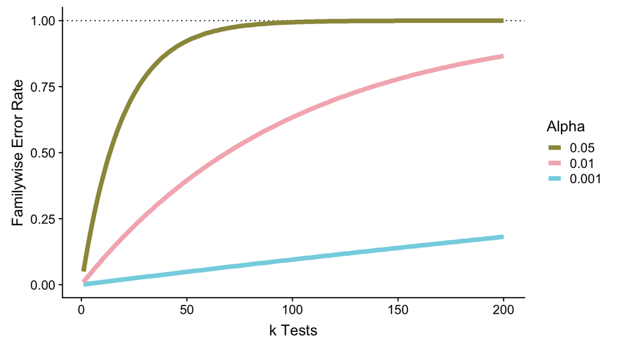

## Quiz 12-1

Lecture 12-2

## References

Bretz, F., T. Hothorn, and P. Westfall. 2010. *Multiple Comparisons Using R*. Taylor & Francis, Boca Raton, FL.

Curran-Everett, D. 2000. Multiple Comparisons: Philosophies and Illustrations. *American Journal of Physiology. Regulatory, Integrative and Comparative physiology* 279:R1–8.

Curran-Everett, D., and D. J. Benos. 2007. Guidelines for Reporting Statistics in Journals Published by the *American Physiological Society*: The Sequel. *Advances in Physiology Education* 31:295–298.

Gelman, A., J. Hill, and M. Yajima. 2012. Why We (Usually) Don’t Have to Worry About Multiple Comparisons. *Journal of Research on Educational Effectiveness* 5:189–211.

Hothorn, T., F. Bretz, and P. Westfall. 2008. Simultaneous Inference in General Parametric Models. *Biometrical Journal* 50:346–363.

Ioannidis, J. P. A. 2005. Why Most Published Research Findings Are False. *PLoS Medicine* 2:e124.

Storey, J. D., and R. Tibshirani. 2003. Statistical Significance for Genomewide Studies. *Proceedings of the National Academy of Sciences of the United States of America* 100:9440–9445.